# 《三体》网络探索分析

### 狗熊会

案例难度：***

案例背景：《三体》是刘慈欣创作的长篇科幻小说系列，由《三体》《三体2：黑暗森林》《三体3：死神永生》组成，作品讲述了地球人类文明和三体文明的信息交流、生死搏杀及两个文明在宇宙中的兴衰历程。《三体》的文本叙事在“后人类”的思考上有着重大突破，构建了科学与文学的互动范式，将道德内涵引入对科技的辩证思考中，并以文学手段在文化语境中对科技进行大胆假设和重构，科幻之外，有着深刻的社会意识。《三体》不仅有宏大的视野，还有丰富的细节，受到广大读者的喜爱，并获得了第73届雨果奖最佳长篇小说奖、2017年轨迹奖最佳长篇科幻小说奖和2021十大年度国家IP等。《三体》中的主人公都有谁？角色之间的关系到底是什么样子的？在本案例中，我们将采用用情感分析和网络分析的方法，对《三体》中的角色关系进行探究。

案例数据：《三体》三部的文本数据。

本案例的学习目标包括：

1. 学会统计文本中的单词词频，及在文本中定位单词。
2. 学会构造基于互动次数和情感得分两个方面的亲密度矩阵。
3. 学会将矩阵转换为网络，并进行网络可视化。
4. 学会对网络进行社区发现，并使用networkD3对划分社区后的网络动态呈现，并学习提取网络社区。
5. 学会可视化网络变化。

## 准备工作

```r
# 读入需要的包
## 分词
library(jiebaRD)
library(jiebaR)
## 数据清洗
library(dplyr)
library(reshape2)
## 网络分析
library(igraph)
library(networkD3)
## 绘图与配色
library(ggplot2)
library(gridExtra)
library(ggsci)

# 配置绘图的颜色向量
mycol = c("#00468BE5","#EE0000E5","#008B45E5","#4500ACB2","#00868BE5","#8e0b0bE5",
          "#5F559BE5","#e81587E5","#808180E5","#FFD700E5","#b0e2ffE5")
```

## 任务一

对《三体》进行分词，并统计角色的段落出场情况。

```r
#读入小说文本
santi = readLines("全文.txt", encoding = "UTF-8")

#通过提取空白字符定位段首
para_head = grep("\\s+", santi, perl = T)
cut_para1 = cbind(para_head[1:(length(para_head)-1)], para_head[-1]-1)

#按段落拼接字符串
santi_para = sapply(1:nrow(cut_para1), function(i) paste(santi[cut_para1[i,1]:cut_para1[i,2]], collapse = ""))

# 查看拼接字符串的前五个元素
head(santi_para)
```

1. '[三体 1-3+三体 X 修订增补] 精校版.刘慈欣'

2. ' 1.科学边界'

3. ' 汪淼觉得，来找他的这四个人是一个奇怪的组合：两名警察和两名军人，如果那两个军人是武警还算正常，但这是两名陆军军官。'

4. ' 汪淼第一眼就对来找他的警察没有好感。其实那名穿警服的年轻人还行，举止很有礼貌，但那位便衣就让人讨厌了。这人长得五大三粗，一脸横肉，穿着件脏兮兮的皮夹克， 浑身烟味，说话粗声大嗓，是最令汪淼反感的那类人。'

5. ' “汪淼？”那人问，直呼其名令汪淼很不舒服，况且那人同时还在点烟，头都不抬一下。不等汪淼回答，他就向旁边那位年轻人示意了一下，后者向汪淼出示了警官证，他点完烟后就直接向屋里闯。'

6. ' “请不要在我家里抽烟。”汪淼拦住了他。'

```r
#读入主角名单数据
roles = readLines("全文人物.txt", encoding = "UTF-8")

#对角色进行统计
roles1 = paste0("(", gsub(" ", ")|(", roles), ")")          #将主角名单改为正则表达式格式
roles_l = strsplit(roles, " ")                              #总结每个人的不同称呼

#计算每个人物名称的出现次数
role_para = sapply(roles1, grepl, santi_para)              #构造人物出场段落矩阵
colnames(role_para) = sapply(roles_l, function(x) x[1])     #以角色第一个称呼重命名矩阵的列

#查看段落矩阵的维度，行数为文章段落数，列数为角色数
dim(role_para)
```

1. 12802

2. 133

解读参考：生成段落的人物矩阵。

## 任务二

构建角色间亲密度矩阵

### 基于互动次数的亲密矩阵

定义互动：两个人名同时出现在一段中则定义为角色间有互动

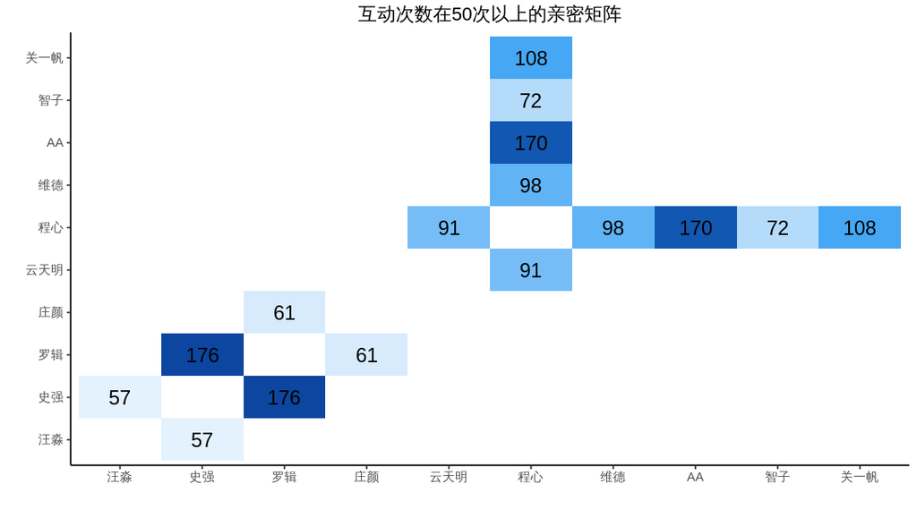

```r
options(repr.plot.width=9,repr.plot.height=5)
#计算亲密度逻辑值
intimacy_main = crossprod(role_para)

#将无意义的矩阵对角线元素化为0
diag(intimacy_main) = 0

#调整数据组织形式以便画图
intimacy_main = melt(intimacy_main)
colnames(intimacy_main) = c("Var1", "Var2", "value")

#绘制亲密度矩阵图
intimacy_main[intimacy_main$value>50,]%>%ggplot(aes(Var1,Var2,fill=value)) +
    geom_tile() +                                                               #绘制矩形块
    geom_text(aes(Var2,Var1,label=value),size=5,color="black") +
    scale_fill_material(palette = "blue")+                                     #设置渐变色
    labs(x = "",y = "",title = "互动次数在50次以上的亲密矩阵") +
    theme_classic()+
    theme(legend.position="none",                                               #删除图例
        plot.title = element_text(hjust = 0.5))
```

解读参考：图中色块的颜色越深表示角色间的亲密度越高，可以看到，罗辑和史强的亲密度最高，文中这两人正是朋友和搭档，程心和AA的亲密度次之，而文中两人也是相互扶持的好友。

### 基于角色间情感倾向的亲密矩阵

定义情感：计算段落情感得分，根据角色互动出现在正/负向段分别赋分，最后根据角色对总得分判断情感倾向

（此部分数据清洗代码较多，所需时间较长。为简便起见，这里直接读入洗好的数据。清洗后的数据包含四列，分别为角色对所处段落、段落情感得分、角色1名称、角色2名称）

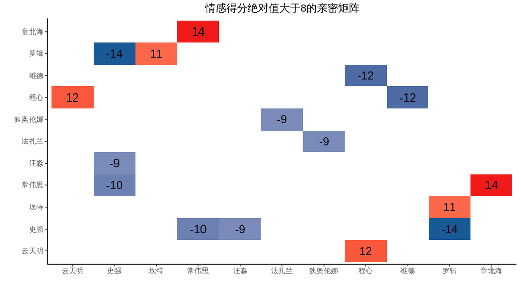

```r
options(repr.plot.width=9,repr.plot.height=5)
# 读入清洗好的角色情感数据
emotionraw = read.csv("情感互动矩阵.csv")

# 统计角色对在全文总的情感得分
emotion = emotionraw %>% group_by(class1,class2) %>% summarise(value = sum(polar),.groups = "drop_last") %>%
  `colnames<-`(value = c("Var1", "Var2", "value"))

# 仅展示情感得分绝对值较大（大于8）的角色对
emotion[abs(emotion$value)>8,]%>%ggplot(aes(Var1,Var2,fill=value)) +
  geom_tile() +                                                               #绘制矩形块
  geom_text(aes(Var2,Var1,label=value),size=5,color="black") +            #矩阵本文
  scale_fill_gradient2(low = mycol[1],midpoint = 0, high = mycol[2]) +
  labs(x = "",y = "",title = "情感得分绝对值大于8的亲密矩阵") +
  theme_classic()+
  theme(legend.position="none",                                               #删除图例
        plot.title = element_text(hjust = 0.5))
```

解读参考：

*罗辑与史强互动次数与情感得分绝对值都很高，但情感倾向却为负，与实际不符，这是因为两人同时出现的片段，情节总有些负面，导致算法对二人的情感关系产生误判。

*章北海和常伟思的互动次数不多，但正向情感得分最高，因为这二人都是深思熟虑、目光广大、深沉果敢的人，彼此之间互相惺惺相惜。

*程心和云天明互动次数和正向情感得分的绝对值都很高，文中两人之间的感情复杂，关系暧昧。

## 任务三

将亲密矩阵转为网络，并进行网络可视化

### 互动网络

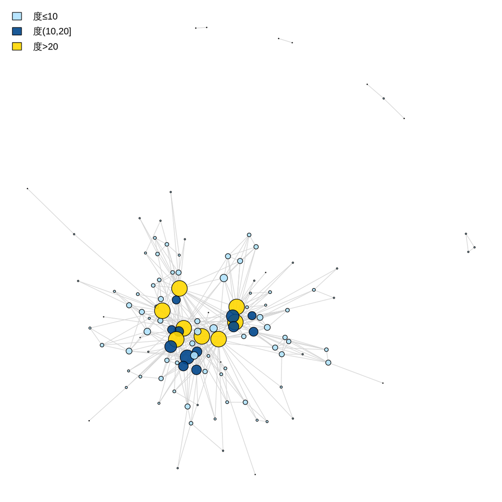

```r
#将数据集转为网络
intimacy_main = intimacy_main[intimacy_main$value>0,]     #仅保留存在互动的角色对
g = graph_from_data_frame(intimacy_main,directed = FALSE) #转为网络型数据
E(g)$weight = intimacy_main$value                         #设置网络边权为

#简化网络，因为亲密矩阵存在重复计算(存在角色1-角色2一行数据；角色2-角色1又有一行)
g = simplify(g)                   #网络去重简化
E(g)$weight = E(g)$weight/2

# 根据度设定节点大小
V(g)$size = ifelse(degree(g)/3<7,degree(g)/3,7)
# 设置节点颜色
V(g)$color = ifelse(degree(g)> 20,mycol[10],ifelse(degree(g)>10,mycol[1],mycol[11]))

# 确定布局并画图
options(repr.plot.width=9,repr.plot.height=9)
par(mfrow=c(1,1), mar = rep(0.1,4))
set.seed(8888)
plot(g,
     vertex.label = NA,        #节点标签
     vertex.size = V(g)$size,  #节点大小
     layout = layout.fruchterman.reingold, #网络构图形式
     edge.color = "lightgrey",
     sub = "角色互动网络全局")
legend("topleft",fill = mycol[c(11,1,10)],  #图例
       legend = c("度≤10","度(10,20]","度>20"),cex=1, bty="n", ncol=1)
```

解读：图中节点数：121 边数：400 密度：5.51% 平均距离：4.91

### 情感网络

具体构建方法与互动网络类似

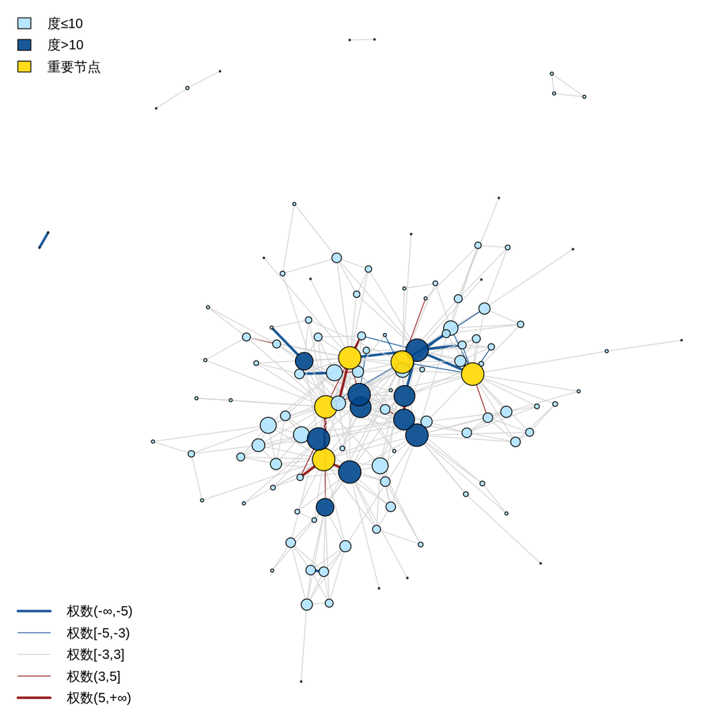

```r
#将数据集转为网络
ge = graph_from_data_frame(emotion[emotion$value != 0,],directed = FALSE)
E(ge)$weight = emotion[emotion$value != 0,]$value

#简化网络，因为亲密矩阵存在重复计算
ge = simplify(ge)
E(ge)$weight = E(ge)$weight/2

# 根据度设定节点大小
V(ge)$size = ifelse(degree(ge)/2<7,degree(ge)/2,7)
# 设置节点颜色
V(ge)$color = ifelse(degree(ge)> 20,mycol[10],ifelse(degree(ge)>10,mycol[1],mycol[11]))
E(ge)$color = ifelse(abs(E(ge)$weight)<4,"lightgrey",ifelse(E(ge)$weight<0,mycol[1],mycol[6]))
E(ge)$width = ifelse(abs(E(ge)$weight)<=5,1,3)


# 边权为负的网络不能用layout.fruchterman.reingold力导向布局，而且会有warning message
ge1 = ge; E(ge1)$weight = abs(E(ge)$weight) # 这里为了图的美化复制这个网络，将其边权暂时都设置为正.但是不改变边权的颜色信息
# 确定布局并画图         (我们后续分析依旧使用有正负边权的ge网络)
options(repr.plot.width=9,repr.plot.height=9)
par(mfrow=c(1,1), mar = rep(0.1,4))
set.seed(8888)
plot(ge1,                  #直接plot ge也可以，但是有warning（无影响）
     vertex.label = NA,
     vertex.size = V(ge1)$size,
     sub = "角色情感联系网络")
## 节点颜色的图例
legend("topleft",fill = mycol[c(11,1,10)],
       legend = c("度≤10","度>10","重要节点"),cex=1, bty="n", ncol=1)
## 边权颜色的图例
legend("bottomleft",
       col = c(mycol[1],mycol[1],'lightgrey',mycol[6],mycol[6]),
       lty = rep(1,5),
       lwd = c(3,1,1,1,3),
       legend = c("权数(-∞,-5)","权数[-5,-3)","权数[-3,3]","权数(3,5]","权数(5,+∞)"),
       cex=1, bty="n", ncol=1)
```

解读参考：节点数：118 边数：343 密度：4.97%

*黄色节点为网络中重要节点，节点间边的颜色代表情感倾向，边的粗细代表两节点间关系的紧密程度

*整体网络中蓝色边较多，说明《三体》整体气氛沉重，情感趋向较消极

## 任务四

对情感网络进行社区发现，使用networkD3对划分社区后的网络动态呈现，并学习提取网络社区。

可以通过以下代码进行社区发现研究，但鉴于每台电脑的随机种子不同，获得的划分结果不同。这里直接读入笔者某次社区发现的结果。

```r
#提取最大联通子图
ge_sub = induced_subgraph(ge, clusters(ge)$membership == which.max(clusters(ge)$csize))

#进行社区发现(社区发现存在随机性，所以需要固定随机种子)
set.seed(5)
#come = cluster_spinglass(ge_sub,weights = E(ge_sub)$weight)
come = read.csv('社区发现结果.csv',fileEncoding = 'GBK')
```

```r
# 将igraph网络转为networkD3网络
g_D3 = igraph_to_networkD3(ge_sub, group = come$membership%>%
                             factor(levels = 1:8,
     labels = c('温馨家庭','阶梯计划', '破壁计划', '地球往事','科学家们','NPC1','三体游戏','NPC2')))
# 为节点添加度属性
g_D3$nodes$Nodesize = ifelse(degree(ge_sub)/2<1,1,degree(ge_sub)/2)
# 为节点添加标签属性
g_D3$nodes$name = names(V(ge_sub))
# 为连边添加权重
g_D3$links$value = E(ge_sub)$Weight
# 为节点添加标签属性
g_D3$nodes$name = ifelse(degree(ge_sub)>5,names(V(ge_sub)),NA)
# 指定单击事件
script = 'alert ("name: " + d.name + ", group: " + d.group + ", size: " + d.nodesize)'
# 绘图
network = forceNetwork(
  Nodes = g_D3$nodes,# 添加节点
  Links = g_D3$links,# 添加连边
  Nodesize = "Nodesize",# 设置节点大小
  NodeID = "name",# 设置节点标签
  Group = "group",# 设置节点社区
  opacity = 0.9,# 设置节点的透明度
  fontFamily = "宋体", # 设置标签字体
  fontSize = 17,# 设置标签字体大小
  linkColour = "#e6e6e6",# 设置连边颜色
    legend = TRUE,
  opacityNoHover = 1,
  colourScale = JS("d3.scaleOrdinal(d3.schemeCategory10);"), # 设置颜色
  radiusCalculation = "d.nodesize",# 设置节点半径计算方式
  clickAction = script,# 设置单击事件
  zoom = TRUE)# 设置是否可以缩放

# 展示动态交互网络
network
```

[interactive chart not shown]

解读参考：

*使用spinglass算法进行社区发现

*不同颜色代表不同社区

*不同节点的大小代表人物在网络中的度

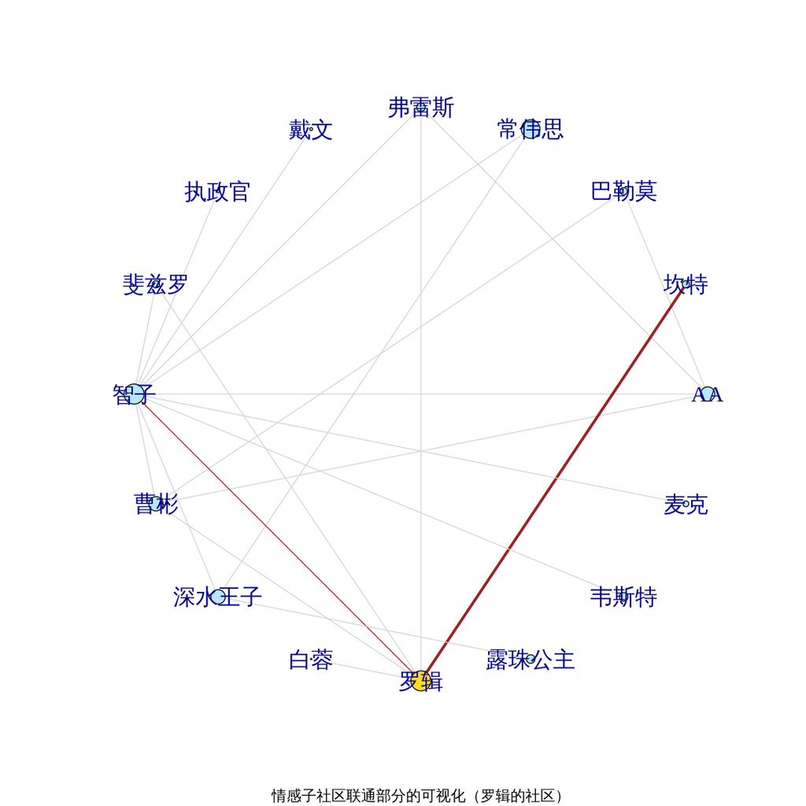

```r
options(repr.plot.width=9,repr.plot.height=9)

# 提取罗辑所在的社区
ge_com = induced_subgraph(ge_sub, come$membership == come$membership[come$names == '罗辑'])
ge_com1 = induced_subgraph(ge_com, clusters(ge_com)$membership == which.max(clusters(ge_com)$csize)) #提取最大联通子图
V(ge_com1)$color = mycol[11]
V(ge_com1)[names(V(ge_com1)) == '罗辑']$color = mycol[10]

par(mfrow = c(1,1))
# 罗辑社区网络绘图
set.seed(888)
plot(ge_com1,
     vertex.label.cex = 1.5,layout = layout.circle,
     sub = '情感子社区联通部分的可视化（罗辑的社区）')
```

## 任务五

重要角色——罗辑在第二部的情感网络变化

```r
#########前三分之一########
#情感网络
emotion1 = emotionraw%>%filter(ind <2788+1662,ind>2788) %>% group_by(class1,class2) %>%
  summarise(value = sum(polar),.groups = "drop_last") %>%`colnames<-`(value = c("Var1", "Var2", "value"))
ge1 = graph_from_data_frame(emotion1,directed = FALSE) #将数据生成网络
E(ge1)$weight = emotion1$value
ge1 = simplify(ge1)              #网络化简
E(ge1)$weight = E(ge1)$weight/2

#设置
V(ge1)$size = ifelse(degree(ge1)<7,degree(ge1),7)
V(ge1)$color = ifelse(names(V(ge1)) == "罗辑",mycol[10],mycol[11])
E(ge1)$color = ifelse(abs(E(ge1)$weight)<4,"lightgrey",ifelse(E(ge1)$weight<0,mycol[1],mycol[6]))
E(ge1)$width = ifelse(abs(E(ge1)$weight)<=3,1,3)
V(ge1)$label = names(V(ge1))
V(ge1)[degree(ge1)<4]$label = NA

#########前三分之二########
#情感网络
emotion2 = emotionraw%>%filter(ind <2788+3325,ind>2788+1662) %>% group_by(class1,class2) %>%
  summarise(value = sum(polar),.groups = "drop_last") %>%`colnames<-`(value = c("Var1", "Var2", "value"))
ge2 = graph_from_data_frame(emotion2,directed = FALSE)
E(ge2)$weight = emotion2$value
ge2 = simplify(ge2)
E(ge2)$weight = E(ge2)$weight/2

#设置
V(ge2)$size = ifelse(degree(ge2)<7,degree(ge2),7)
V(ge2)$color = ifelse(names(V(ge2)) == "罗辑",mycol[10],mycol[11])
E(ge2)$color = ifelse(abs(E(ge2)$weight)<4,"lightgrey",ifelse(E(ge2)$weight<0,mycol[1],mycol[6]))
E(ge2)$width = ifelse(abs(E(ge2)$weight)<=3,1,3)
V(ge2)$label = names(V(ge2))
V(ge2)[degree(ge2)<4]$label = NA

#########后三分之一########
#亲密网络
emotion3 = emotionraw%>%filter(ind <2788+4988,ind>2788+3325) %>% group_by(class1,class2) %>%
  summarise(value = sum(polar),.groups = "drop_last") %>%`colnames<-`(value = c("Var1", "Var2", "value"))
ge3 = graph_from_data_frame(emotion3,directed = FALSE)
E(ge3)$weight = emotion3$value
ge3 = simplify(ge3)
E(ge3)$weight = E(ge3)$weight/2

#设置
V(ge3)$size = ifelse(degree(ge3)<7,degree(ge3),7)
V(ge3)$color = ifelse(names(V(ge3)) == "罗辑",mycol[10],mycol[11])
E(ge3)$color = ifelse(abs(E(ge3)$weight)<4,"lightgrey",ifelse(E(ge3)$weight<0,mycol[1],mycol[6]))
E(ge3)$width = ifelse(abs(E(ge3)$weight)<=3,1,3)
V(ge3)$label = names(V(ge3))
V(ge3)[degree(ge3)<4]$label = NA
```

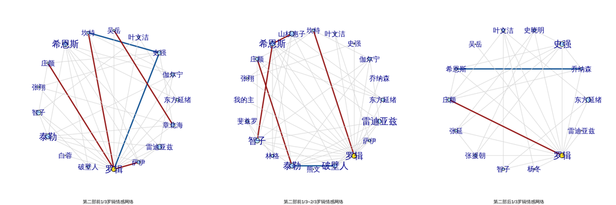

```r
options(repr.plot.width=15,repr.plot.height=5)

##### 只看罗辑的领域网络变化####
par(mfrow = c(1,3))
gen1 = induced_subgraph(ge1,neighborhood(ge1)[[which(names(V(ge1)) == "罗辑")]])
plot(gen1,vertex.label = names(V(gen1)),layout = layout.circle,
     vertex.label.cex = ifelse(degree(gen1)>5,2,1.5),sub = "第二部前1/3罗辑情感网络")

gen2 = induced_subgraph(ge2,neighborhood(ge2)[[which(names(V(ge2)) == "罗辑")]])
plot(gen2,vertex.label = names(V(gen2)),layout = layout.circle,
     vertex.label.cex = ifelse(degree(gen2)>5,2,1.5),sub = "第二部前1/3~2/3罗辑情感网络")

gen3 = induced_subgraph(ge3,neighborhood(ge3)[[which(names(V(ge3)) == "罗辑")]])
plot(gen3,vertex.label = names(V(gen3)),layout = layout.circle,
     vertex.label.cex = ifelse(degree(gen3)>5,2,1.5),sub = "第二部后1/3罗辑情感网络")
```

解读参考：

*前期的罗辑虽然已经被推选为面壁者，但他沉迷于情爱并没有承担起责任。另一方面，由于三体惧怕罗辑，因此罗辑频频遭到追杀，史强作为他的保护者，也连带遭殃，因而情感倾向较为负面。

*到了中期，政府组织以庄颜为要挟，罗辑开始正式承担起面壁者的责任。与他交往密切并且情感积极的人物，大多是同一战营的伙伴。

*后期的罗辑，为了给冬眠的爱人一个和平的世界，他再次承担起重任，成为执剑人，独自一人维系着地球与三体间博弈的平衡，为地球挣得近百年的和平。